# Confidence Intervals (p. 53)

Data Analysis for the Life Sciences CUNY School of Public Health Waldron Book Club

January 11, 2016

### Get started downloading the data

```r
library(downloader)
library(dplyr)
url <- "https://raw.githubusercontent.com/genomicsclass/dagdata/master/inst/extdata/mice_pheno.csv"
filename <- "mice_pheno.csv"
if (!file.exists(filename)) {
  download(url, destfile = filename)
  }
dat <- read.csv("mice_pheno.csv")
```

Reporting just p-values is not enough. p-values only indicate statistical significance which does not guarantee scientific/clinical significance. A large sample size allows the detection of a tiny difference that may not be relevant to clinical outcomes. p-values do not report effect size (observed difference).

### Confidence Interval for Population Mean (female mice on chow diet)

```r
chowPopulation <- dat[dat$Sex=="F" & dat$Diet=="chow",3]
(mu_chow <- mean(chowPopulation))
```

```
## [1] 23.89338
```

In practice, we don’t know the true population parameter. We rely on random samples to estimate the population mean. Let’s take a sample size of 30 (N = 30).

```r
set.seed(1) # set a seed for random number generation
chow <- sample(chowPopulation, 30)
chow %>% mean
```

```
## [1] 23.351
```

With a sample size of 30, we will use the CLT. The CLT tells us that $\bar{X}$ or `mean(chow)` follows a normal distribution with mean $\mu_X$ or `mean(chowPopulation)`

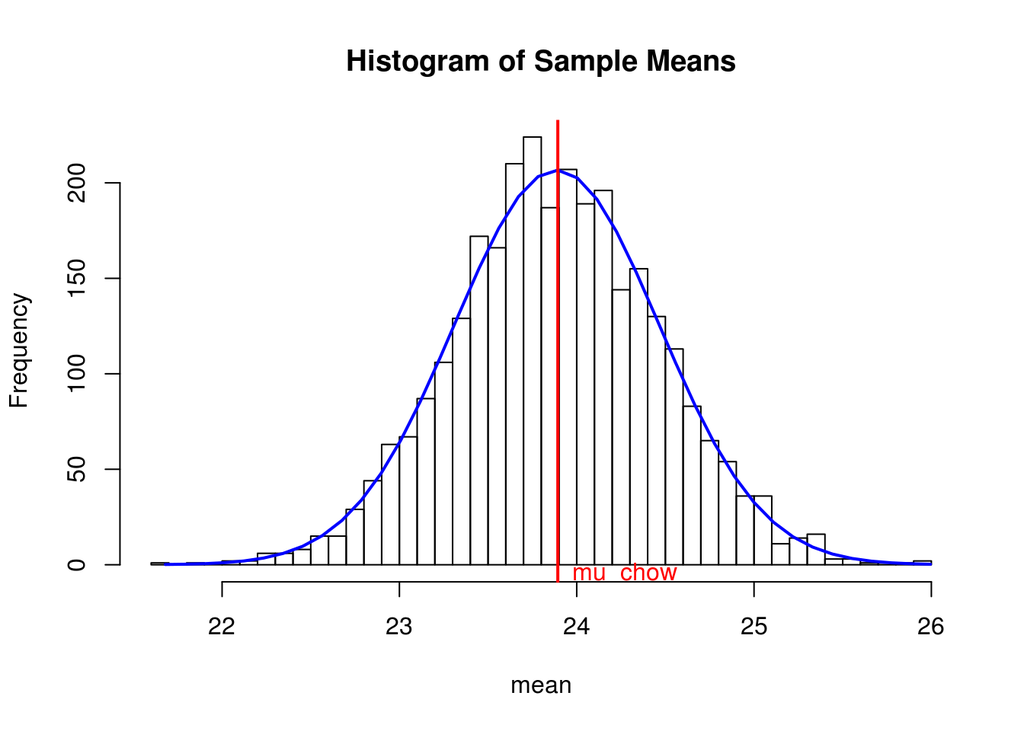

```r
N <- 30
sampl <- rep(NA, 3000)
for(i in 1:3000){
  sampl[i] <- sample(chowPopulation, N) %>% mean
}
h <- hist(sampl, 50, main = "Histogram of Sample Means", xlab = "mean")
xfit<-seq(min(sampl),max(sampl),length=40)
yfit<-dnorm(xfit,mean=mean(sampl),sd=sd(sampl))
yfit <- yfit*diff(h$mids[1:2])*length(sampl)
lines(xfit, yfit, col="blue", lwd=2)
abline(v = mu_chow, col = "red", lwd = 2)
text(x = mu_chow, y = -5, labels = "mu_chow", col = "red", pos = 4)
```

and standard error approximately $s_X/\sqrt{N}$ or:

```r
(se <- sd(chow)/sqrt(N))
```

```
## [1] 0.4781652
```

### Defining the Interval

The 95% confidence interval is commonly used although percentages other than 95 can be used. It is a random interval with a 95% probability of falling on the parameter we are estimating. This is *not* the same as saying there is a 95% chance that the true value falls in our interval. To construct it, we note that the CLT tells us that $\sqrt{N} (\bar{X}-\mu_X) / s_X$ follows a normal distribution with mean 0 and SD 1. This implies that the probability of this event:

$-2 \leq \sqrt{N} (\bar{X}-\mu_X)/s_X \leq 2$

```r
pnorm(2) - pnorm(-2)
```

```
## [1] 0.9544997
```

```r
Q <- qnorm(1-0.05/2)
pnorm(Q) - pnorm(-Q)
```

```
## [1] 0.95
```

After basic algebra:

$\bar{X}-2 s_X/\sqrt{N} \leq \mu_X \leq \bar{X}+2s_X/\sqrt{N}$

Let’s demonstrate this logic through simulation. We can construct this interval with R relatively easily:

```r
interval <- c(mean(chow)-Q*se, mean(chow)+Q*se )
interval
```

```
## [1] 22.41381 24.28819
```

```r
interval[1] < mu_chow & interval[2] > mu_chow
```

```
## [1] TRUE
```

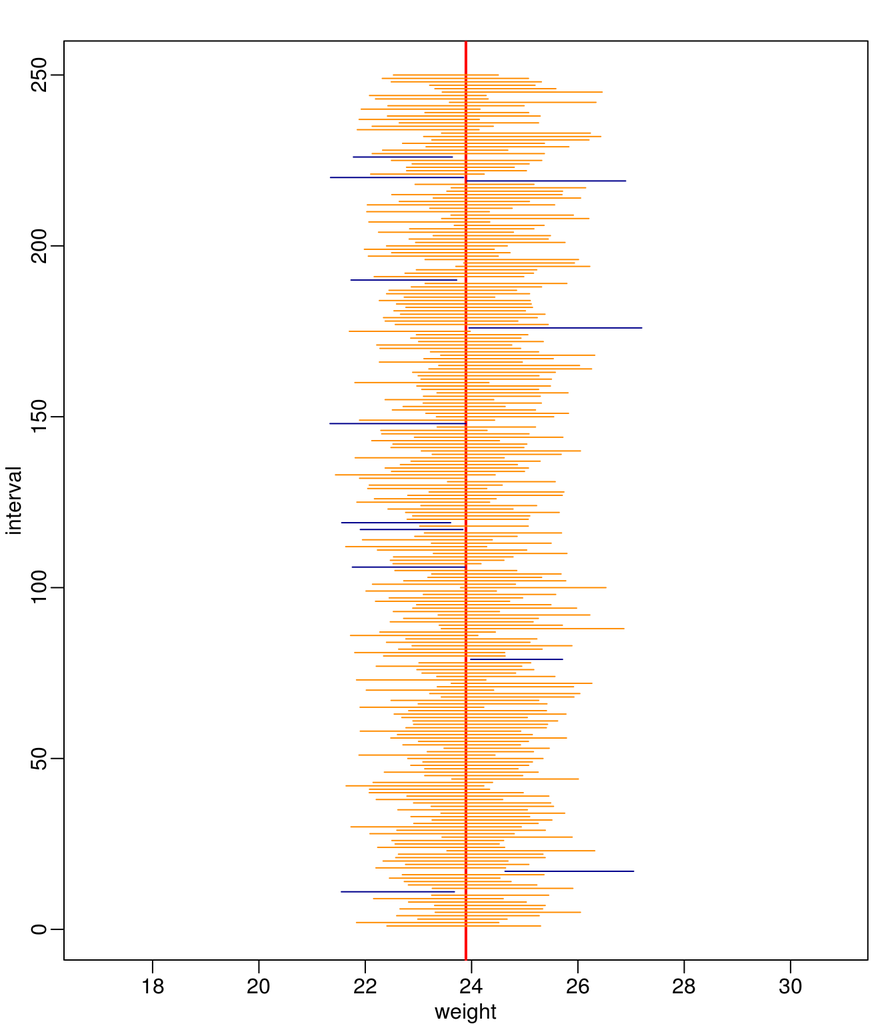

```r
library(rafalib)
B <- 250 # number of iterations
mypar()
plot(mean(chowPopulation)+c(-7,7),c(1,1),type="n",
     xlab="weight",ylab="interval",ylim=c(1,B)) # draw an empty plot with allocated space
abline(v=mean(chowPopulation), col = "red", lwd = 2) # add line denoting population mean
for (i in 1:B) {
  chow <- sample(chowPopulation,N)
  se <- sd(chow)/sqrt(N)
  interval <- c(mean(chow)-Q*se, mean(chow)+Q*se)
  covered <-
    mean(chowPopulation) <= interval[2] & mean(chowPopulation) >= interval[1]
  color <- ifelse(covered,"darkorange","darkblue")
  lines(interval, c(i,i),col=color)
} # run loop by plotting a line for each iteration
```

Run repeatedly to see what happens… (shortcut keys = Ctrl + Alt + C)

#### Small Sample Size And The CLT

For $N=30$, the CLT works very well. However, if $N=5$, do these confidence intervals work as well? We used the CLT to create our intervals, and with $N=5$ it may not be as useful an approximation. We can confirm this with a simulation:

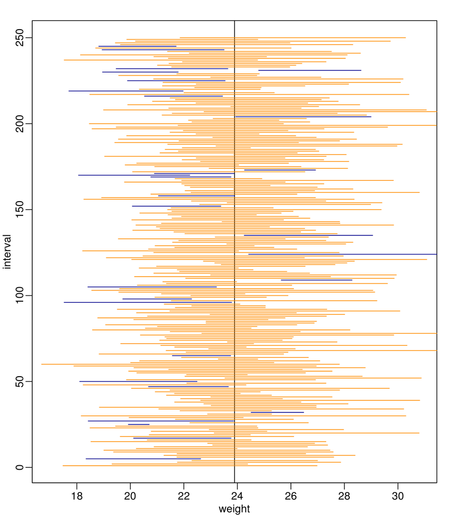

```r
mypar()
plot(mean(chowPopulation)+c(-7,7),c(1,1),type="n",
     xlab="weight",ylab="interval",ylim=c(1,B))
abline(v=mean(chowPopulation))
Q <- qnorm(1- 0.05/2)
N <- 5
for (i in 1:B) {
  chow <- sample(chowPopulation,N)
  se <- sd(chow)/sqrt(N)
  interval <- c(mean(chow)-Q*se, mean(chow)+Q*se)
  covered <- mean(chowPopulation) <= interval[2] & mean(chowPopulation) >= interval[1]
  color <- ifelse(covered,"darkorange","darkblue")
  lines(interval, c(i,i),col=color)
}
```